# Spatial Transcriptomic Analyses of Bioengineered Porcine Oesophaus

George T. Hall

Compiled on 21 January 2026

# 1 Preamble

**`harmony` bugfix**

```r
# This is a bugfix. For some reason, runnibng RunUMAP() is necessary before
# running Harmony (otherwise all the embeddings are NaN). However, it's
# not necessary to actually store / use the result. It turns out that
# it's actually just the uwot function that needs to be run, but it is
# unclear why (probably due to Rcpp or something?). For now, we run it here on
# dummy data just to fix Harmony. Ideally, we wouldn't run this
# function just to fix Harmony
uwot:::uwot(matrix(1:40, nrow = 20))
```

```
##              [,1]        [,2]
##  [1,] -2.81858713 -0.76869722
##  [2,] -2.62279970 -0.51957120
##  [3,] -2.24476797 -0.71316530
##  [4,] -2.46325571 -1.11586149
##  [5,] -2.03355915 -1.32831158
##  [6,] -1.64556295 -1.10733403
##  [7,] -1.33366234 -0.66709448
##  [8,] -0.89437563 -0.56790169
##  [9,] -0.46671326 -0.33749570
## [10,] -0.03959257 -0.51353203
## [11,]  0.14079540 -0.07929633
## [12,]  0.66567963 -0.14262889
## [13,]  1.14963859  0.25289528
## [14,]  1.57443326  0.44548778
## [15,]  2.08097547  0.51634751
## [16,]  1.75193089  1.04127441
## [17,]  2.13189858  1.05909847
## [18,]  2.41180795  1.69111525
## [19,]  2.10834973  1.50112854
## [20,]  2.54736691  1.35354267
## attr(,"scaled:center")
## [1] -4.4366571  0.1813553
```

We set the random seed before proceeding.

```r
set.seed(123)
```

## 1.1 Preliminary function definitions

In this section, we define some functions that we will use throughout the rest of this notebook. Each definition is hidden by default.

**`VolPlot` function**

```r
VolPlot <- function(marks, to_label) {
    marks$gene <- rownames(marks)
    marks$p_val_adj_neg_log <- -1 * log10(marks$p_val_adj)
    y_upper_lim <- 330
    inf_idxs <- is.infinite(marks$p_val_adj_neg_log)
    marks$p_val_adj_neg_log[inf_idxs] <- y_upper_lim
    marks$is_inf <- inf_idxs
    pos_lfc_lower_lim <- 1
    neg_lfc_upper_lim <- -1
    sig_marks_pos <- subset(marks, avg_log2FC > pos_lfc_lower_lim)
    sig_marks_neg <- subset(marks, avg_log2FC < neg_lfc_upper_lim)
    max_abs_lfc <- max(abs(marks$avg_log2FC))

    # Assign classes to genes based on how DE they are. Used to set colours
    de_class <- ifelse(marks$avg_log2FC < neg_lfc_upper_lim & marks$p_val_adj < 0.01,
                       "Downreg",
                       ifelse(marks$avg_log2FC > pos_lfc_lower_lim & marks$p_val_adj < 0.01,
                              "Upreg",
                              ifelse(marks$p_val_adj < 0.01,
                                     "Low-LFC", "Not-Sig")))
    de_class <- factor(de_class, levels = c("Not-Sig", "Low-LFC",
                                            "Downreg", "Upreg"))

    genes_to_label <- subset(marks, gene %in% to_label)
    points_alpha <- 0.5
    plot <- ggplot(marks, aes(x = avg_log2FC, y = p_val_adj_neg_log,
                              label = rownames(marks))) +
            geom_point(aes(color = avg_log2FC),
                       size = 2, stroke = NA) +
            scale_color_viridis_c(option = "plasma", alpha = points_alpha) +
            guides(color = guide_colorbar(bquote(Log["2"]~"fold change"))) +
            geom_text_repel(data = genes_to_label, aes(label = gene),
                            min.segment.length = 0, size = 4,
                            force = 10, segment.alpha = 0.5,
                            max.overlaps = 50, fontface = "bold", seed = 456) +
            xlim(-max_abs_lfc, max_abs_lfc) +
            ylim(-log10(0.01), min(y_upper_lim, max(marks$p_val_adj_neg_log))) +
            xlab(bquote(Log["2"]~"fold change")) +
            ylab(bquote(-Log["10"] ~ P)) +
            theme(panel.grid.major = element_blank(),
                  panel.grid.minor = element_blank(),
                  panel.background = element_blank(),
                  axis.line = element_line(color = "black")) +
            coord_cartesian(clip = "off")

    return(plot)
}
```

**`add_visual_reduction`**

```r
add_visual_reduction <- function(cell_obj) {
    old_default_assay <- DefaultAssay(cell_obj)
    DefaultAssay(cell_obj) <- "Spatial"
    visual_coords <- GetTissueCoordinates(cell_obj)
    colnames(visual_coords) <- c("visual_1", "visual_2")
    vis_coords_mat <- as.matrix(visual_coords)
    cell_obj@reductions$visual <- CreateDimReducObject(key = "visual_",
                                                       embeddings = vis_coords_mat,
                                                       assay = "Spatial")
    DefaultAssay(cell_obj) <- old_default_assay

    return(cell_obj)
}
```

**`get_sample_name_from_plot`**

```r
# Work out the sample name based on the number of spots in the plot.
get_sample_name_from_plot <- function(p) {
    # prepend "x" so that don't start with number
    sample_name <- switch(paste0("x", nrow(p$data)),
           x2783 = "Native_1_ST",
           x2519 = "Native_2_ST",
           x2995 = "Native_3_ST",
           x2974 = "Cher_native_V",
           x2296 = "Fergie_Graft_V",
           x2816 = "Cher_Graft_V",
           x2147 = "Cher_ReCell_V",
           x3704 = "Adele_Graft_V",
           x2768 = "Beyonce_Graft_V",
           x2458 = "Dolly_Graft_V",
           x3452 = "Ella_Graft_V")

    return(sample_name)
}
```

**`FixSpatialPlot`**

```r
FixSpatialPlot <- function(p, sample_name = NULL) {
    if (is.null(sample_name)) {
        sample_name <- get_sample_name_from_plot(p)
        if (is.null(sample_name)) {
            return(p)
        }
    }

    point_size_factors <- list("Native_1_ST" = 1.5, "Native_2_ST" = 1.55,
                               "Native_3_ST" = 1.6, "Cher_native_V" = 1.6,
                               "Fergie_Graft_V" = 1.7, "Cher_Graft_V" = 1.6,
                               "Cher_ReCell_V" = 1.7, "Adele_Graft_V" = 1.4,
                               "Beyonce_Graft_V" = 1.45, "Dolly_Graft_V" = 1.6,
                               "Ella_Graft_V" = 1.5)

    p$layers[[1]]$aes_params$point.size.factor <- point_size_factors[[sample_name]]

    return(p)
}
```

**`DotPlot_square`**

```r
DotPlot_square <- function(dot_plot, sig_degs) {
    if (!is.null(sig_degs)) {
        sig_degs <- sig_degs[sig_degs$features.plot %in% dot_plot$features.plot, ]
        sig_degs$id <- as.factor(sig_degs$id)
    }

    l <- lapply(unique(dot_plot$features.plot),
                                      function(x) {
                                          max_idxs <- which.max(dot_plot[dot_plot$features.plot == x, "lfc"])
                                          return(levels(dot_plot$id)[max_idxs])
                                      })
    max_clust_df <- data.frame(gene = unique(dot_plot$features.plot), max_clust_idx = unlist(l))
    max_clust_df$max_clust_idx <- factor(max_clust_df$max_clust_idx, levels = levels(dot_plot$id))
    max_clust_df$lfc <- apply(max_clust_df, 1,
                              function(x) {
                                  subset(dot_plot,
                                         (id == x[2]) & (features.plot == x[1]))$lfc
                              })
    genes_ordered <- max_clust_df[with(max_clust_df, order(max_clust_idx, -lfc)), ]$gene
    dot_plot$features.plot <- as.character(dot_plot$features.plot)
    dot_plot$features.plot <- factor(dot_plot$features.plot, levels = genes_ordered)

    min_max <- max(abs(dot_plot$lfc))

    p <- ggplot(mapping = aes(x = id, y = features.plot)) +
            geom_point(data = dot_plot, aes(color = lfc), shape = "square",
                       size = 13)
    if (!is.null(sig_degs)) {
        p <- p + geom_point(data = sig_degs, color = "black", shape = "circle", size = 3) +
                geom_point(data = sig_degs, color = "white", shape = "circle", size = 2)
    }
    p <- p + scale_colour_gradient2(high = "#82001E", low = "#003576",
                                    name = bquote(Log["2"]~"fold change"),
                                    limits = c(-min_max, min_max)) +
            theme_bw() +
            xlab("Cluster number") +
            ylab("Gene")

    return(p)
}
```

**`custom_FindMarkers`**

```r
custom_FindMarkers <- function(seu, grouping_col, md_colnames, idents_1,
                               idents_2, latent_vars = NULL, pbulk_by = NULL) {
    if (length(md_colnames) == 0) {
        stop("md_colnames must be a vector of length > 1")
    }

    cells_1_barcodes <- colnames(seu[, seu@meta.data[, grouping_col] %in% idents_1])
    cells_2_barcodes <- colnames(seu[, seu@meta.data[, grouping_col] %in% idents_2])
    seu <- seu[, c(cells_1_barcodes, cells_2_barcodes)]

    if (!is.null(pbulk_by)) {
        df <- seu@meta.data[, c(pbulk_by, md_colnames)]
        df <- aggregate(df[, -which(colnames(df) == pbulk_by)],
                        list(df[, pbulk_by]), mean) %>%
                t()
        colnames(df) <- df[1, ]
        df <- df[-1, ]
        old_row_names <- rownames(df)
        df <- apply(df, 2, as.numeric)
        rownames(df) <- old_row_names

        lv_list <- lapply(latent_vars, function(x) {
                              tab <- table(seu[[pbulk_by]][, 1],
                                           seu[[x]][, 1])
                              apply(tab, 1, which.max) %>%
                                as.numeric()
                        })
        lv_df <- as.data.frame(lv_list)
        colnames(lv_df) <- latent_vars
        rownames(lv_df) <- colnames(df)
        cells_1_barcodes <- unique(seu[, cells_1_barcodes][[pbulk_by]][, 1])
        cells_2_barcodes <- unique(seu[, cells_2_barcodes][[pbulk_by]][, 1])
    } else {
        df <- t(seu@meta.data[, md_colnames, drop = FALSE])
        lv_df <- seu@meta.data[, latent_vars, drop = FALSE]
    }

    marks <- Seurat:::LRDETest(data.use = df, cells.1 = cells_1_barcodes,
                               cells.2 = cells_2_barcodes, latent.vars = lv_df)
    marks$p_val_adj <- sapply(marks$p_val,
                              function(x) {
                                  min(x * nrow(marks), 1)
                              })
    marks$gene <- rownames(marks)

    return(marks)
}
```

**`change_color_scale`**

```r
change_color_scale <- function(plot_list, gene_name) {
    all_data <- lapply(plot_list,
                       function(x) {
                           x$data[, gene_name]
                       }) %>%
        unlist()
    lims <- c(min(all_data), max(all_data))
    plot_list <- lapply(plot_list,
                        function(x) {
                            x + scale_fill_viridis_c(option = "plasma",
                                                     limits = lims)
                        })

    return(plot_list)
}
```

**`run_fgsea`**

```r
run_fgsea <- function(in_marks, gene_sets)  {
    ranks <- in_marks %>%
             arrange(desc(avg_log2FC)) %>%
             dplyr::select(gene, avg_log2FC) %>%
             tibble::deframe()

    set.seed(123)
    fgsea_res <- fgsea(gene_sets, stats = ranks) %>%
                    as_tibble() %>%
                    arrange(desc(NES))
    fgsea_res$is_signif <- fgsea_res$padj <= 0.05

    return(fgsea_res)
}
```

## 1.2 Load libraries

Load the R libraries required in the analysis. Also set some options for the generation of this document.

```r
knitr::opts_chunk$set(results = 'hide', message = FALSE, warning = FALSE,
                      error = FALSE, fig.align = "center", out.width = "75%")
# compilation_level controls whether some chunks are not evaluated to save
# time. Note that chunks may be skipped with eval = FALSE for other reasons
# outside of compilation_level = 1.
# compilation_level = 0: Skip time-consuming chunks
# compilation_level = 1: Do not skip chunks
compilation_level <- 1

library(dplyr)
library(Seurat)
library(SeuratDisk)
library(sctransform)
library(harmony)
library(patchwork)
library(ggplot2)
library(ggpubr)
library(ggrepel)
library(plotly)
library(openxlsx)
library(DESeq2)
library(BiocParallel)
library(msigdbr)
library(fgsea)
library(entropy)
library(clustree)
library(SCINA)
library(SingleCellExperiment)
library(DAseq)
```

## 1.3 Other preamble

Miscellaneous stuff that needs to happen before the rest of the code, e.g. renaming genes from the pig reference to human names.

```r
cells <- list()

s_genes <- cc.genes$s.genes
g2m_genes <- cc.genes$g2m.genes

hcop_db <- read.csv(file = "data/human_pig_hcop_fifteen_column.tsv",
                    sep = "\t")

new_gene_name <- function(old_gene_name, hcop_db) {
    if (substr(old_gene_name, 1, 7) != "ENSSSCG") {
        return(old_gene_name)
    }

    idx <- match(old_gene_name, hcop_db$pig_ensembl_gene)

    if (is.na(idx)) {
        # Not in HCOP list
        return (old_gene_name)
    }

    row <- hcop_db[idx, ]
    pig_symb <- row$pig_symbol
    human_symb <- row$human_symbol

    if (substr(pig_symb, 1, 3) == "LOC" & human_symb != "-") {
        new_name <- paste0("hl_", human_symb)
    } else if (pig_symb != "-") {
        new_name <- paste0("p_", pig_symb)
    } else if (human_symb != "-") {
        new_name <- paste0("h_", human_symb)
    } else {
        return(old_gene_name)
    }

    return(paste0(old_gene_name, " (", new_name, ")"))
}
```

# 2 Single-nucleus data

## 2.1 Load data

Load the datasets from file.

```r
for (s in c("P1", "P2_R", "P3")) {
    dir_name <- paste0("data/", s, "/filtered_feature_bc_matrix")
    mat <- Read10X(dir_name)
    cells[[s]] <- CreateSeuratObject(mat)
    cells[[s]]$sample_multiplex <- s

    vireo_no_geno_out_path <- paste0("data/", s, "/donor_ids.tsv")
    vireo_no_geno_out <- read.csv(vireo_no_geno_out_path, sep = "\t")

    vireo_with_geno_out_path <- paste0("data/", s, "/donor_ids_with_geno.tsv")
    vireo_with_geno_out <- read.csv(vireo_with_geno_out_path, sep = "\t")

    cell_idxs_no_geno <- match(vireo_no_geno_out$cell, colnames(cells[[s]]))
    cells[[s]]$sample_vireo_no_geno <- paste0(s, "_", vireo_no_geno_out$donor_id[cell_idxs_no_geno])

    cell_idxs_with_geno <- match(vireo_with_geno_out$cell, colnames(cells[[s]]))
    cells[[s]]$sample_vireo_with_geno <- paste0(s, "_", vireo_with_geno_out$donor_id[cell_idxs_with_geno])

    tab <- table(cells[[s]]$sample_vireo_no_geno,
                 cells[[s]]$sample_vireo_with_geno)
    tab <- tab[, grepl("doublet|unassigned", colnames(tab)) == FALSE]
    donor0_alias <- names(which.max(tab[rownames(tab) == paste0(s, "_donor0"), ]))
    donor1_alias <- names(which.max(tab[rownames(tab) == paste0(s, "_donor1"), ]))

    if (donor0_alias == donor1_alias) {
        warning(paste("s", s, ": donor0_alias == donor1_alias"))
    }

    cells[[s]]$sample_vireo_no_geno_unaliased <- cells[[s]]$sample_vireo_no_geno
    cells[[s]]$sample_vireo_no_geno_unaliased[cells[[s]]$sample_vireo_no_geno == paste0(s, "_donor0")] <- donor0_alias
    cells[[s]]$sample_vireo_no_geno_unaliased[cells[[s]]$sample_vireo_no_geno == paste0(s, "_donor1")] <- donor1_alias

    cellbender_barcodes_path <- paste0("data/", s, "/", s,
                                       "_cellbender_cell_barcodes.csv")
    cellbender_barcodes <- read.csv(cellbender_barcodes_path, header = FALSE)$V1
    cells[[s]] <- cells[[s]][, cellbender_barcodes]

    doublet_or_unassigned <- grepl(pattern = "doublet|unassigned",
                                   x = cells[[s]]$sample_vireo_no_geno_unaliased)
    cells[[s]] <- cells[[s]][, doublet_or_unassigned == FALSE]
    cells[[s]]$sample <- cells[[s]]$sample_vireo_no_geno_unaliased
}

cells$P1$sample[cells$P1$sample == "P1_PVA"] <- "AdeleInjectedCells"
cells$P1$sample[cells$P1$sample == "P1_PVC"] <- "DollyRecellSN"
cells$P2_R$sample[cells$P2_R$sample == "P2_R_Fergie-Graft"] <- "FergieRecellSN"
cells$P2_R$sample[cells$P2_R$sample == "P2_R_PVC"] <- "DollyInjectedCells"
cells$P3$sample[cells$P3$sample == "P3_Fergie-Graft"] <- "FergieInjectedCells"
cells$P3$sample[cells$P3$sample == "P3_PVA"] <- "AdeleRecellSN"

for (s in c("CherInjectedCells", "CherRecellSN")) {
    file_name <- paste0("data/", s, "/", s, "_cellbender_filtered.h5")
    mat <- Read10X_h5(file_name)
    true_barcodes <- colnames(mat)

    dir_name <- paste0("data/", s, "/filtered_feature_bc_matrix")
    mat <- Read10X(dir_name)
    mat <- mat[, colnames(mat) %in% true_barcodes]

    cells[[s]] <- CreateSeuratObject(mat)

    cells[[s]]$sample <- s
}

for (s in names(cells)) {
    cells[[s]]$lane <- s

    if (s %in% c("CherInjectedCells", "CherRecellSN")) {
        cells[[s]]$technology <- "one"
    } else {
        cells[[s]]$technology <- "two"
    }
}
```

## 2.2 Merge samples

Merge all SN samples into one Seurat object and filter based on number of genes and molecules.

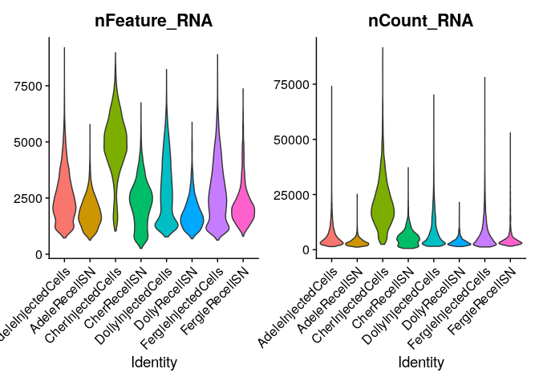

```r
cells$all_sn <- merge(x = cells$CherInjectedCells,
                      y = c(cells$CherRecellSN, cells$P1, cells$P2_R,
                            cells$P3))

VlnPlot(cells$all_sn, c("nFeature_RNA", "nCount_RNA"), pt.size = 0,
        group.by = "sample")
```

```r
qc_df <- t(data.frame(c("AdeleInjectedCells", 6500, 20000),
                      c("AdeleRecellSN", 5000, 15000),
                      c("CherInjectedCells", 8000, 60000),
                      c("CherRecellSN", 5000, 20000),
                      c("DollyInjectedCells", 6500, 35000),
                      c("DollyRecellSN", 5000, 15000),
                      c("FergieInjectedCells", 7000, 30000),
                      c("FergieRecellSN", 5500, 25000))) %>%
            as.data.frame()
rownames(qc_df) <- NULL
colnames(qc_df) <- c("sample", "nFeature_max", "nCount_max")
qc_df$nFeature_max <- as.numeric(qc_df$nFeature_max)
qc_df$nCount_max <- as.numeric(qc_df$nCount_max)

sample_idx <- match(cells$all_sn$sample, qc_df$sample)
pass_qc_idx <- cells$all_sn$nFeature_RNA <= qc_df[sample_idx, "nFeature_max"] &
               cells$all_sn$nCount_RNA <= qc_df[sample_idx, "nCount_max"]
cells$all_sn <- cells$all_sn[, pass_qc_idx]

DefaultAssay(cells$all_sn) <- "RNA"
cells$all_sn <- NormalizeData(cells$all_sn) %>%
                    FindVariableFeatures() %>%
                    ScaleData() %>%
                    RunPCA() %>%
                    RunHarmony("lane") %>%
                    RunUMAP(dims = 1:20, reduction = "harmony")

cells$all_sn$before_after <- "Before"
after_samples <- c("AdeleRecellSN", "CherRecellSN", "DollyRecellSN",
                   "FergieRecellSN")
cells$all_sn$before_after[cells$all_sn$sample %in% after_samples] <- "After"
```

## 2.3 Find DEGs and DE gene sets (pre- vs post-)

Compute differentially expressed genes between pre- and post-bioreactor nuclei. Map these to differentially expressed gene sets.

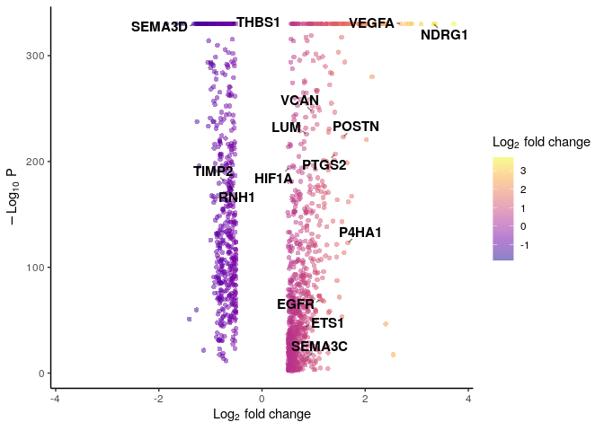

```r
hallmark_gene_sets <- msigdbr(species = "Sus scrofa", category = "H") %>%
                        split(x = .$gene_symbol, f = .$gs_name)

to_label <- c("SEMA3C", "VEGFA", "HIF1A", "P4HA1", "PLAUR", "PTGS2",
              "THBS1", "TIMP1", "SEMA3D", "NDRG1", "EGFR", "ETS1", "POSTN",
              "VCAN", "LUM", "TIMP2", "RNH1")

marks_after_before <- FindMarkers(cells$all_sn, group.by = "before_after",
                                  ident.1 = "After", ident.2 = "Before",
                                  latent.vars = c("technology", "lane"),
                                  test.use = "LR")
marks_after_before$gene <- rownames(marks_after_before)
marks_after_before <- marks_after_before[order(marks_after_before$avg_log2FC, decreasing = TRUE), ]
marks_before_after_to_plot <- marks_after_before[abs(marks_after_before$avg_log2FC) > 0.5, ]
out_spreadsheet <- createWorkbook()
worksheet_name <- "degs"
addWorksheet(out_spreadsheet, worksheet_name)
writeData(out_spreadsheet, worksheet_name, marks_after_before,
          rowNames = FALSE)
file_name <- paste0("out_data/after_before_degs_all_sn_lane_covar_LR_test.xlsx")
saveWorkbook(out_spreadsheet, file_name, overwrite = TRUE)
file_name <- paste0("out_data/after_before_degs_all_sn_lane_covar_LR_test.csv")
write.csv(marks_after_before, file = file_name)

marks_before_after_to_plot[marks_before_after_to_plot$gene == "ENSSSCG00000017164", "gene"] <- "TIMP2"
rownames(marks_before_after_to_plot) <- marks_before_after_to_plot$gene
p <- VolPlot(marks_before_after_to_plot, to_label)
print(p)
```

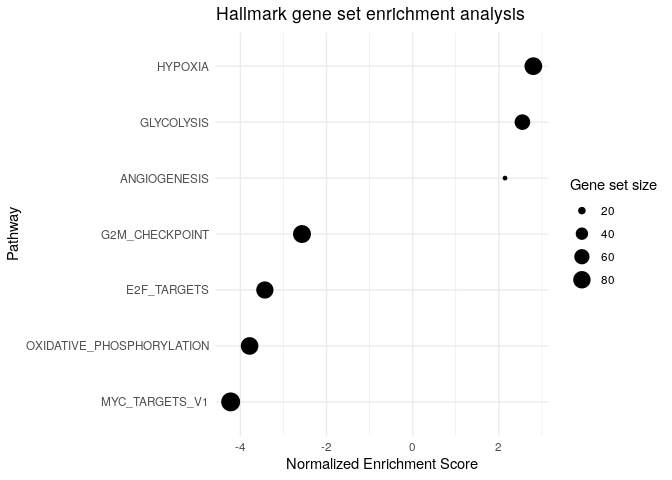

```r
ggsave(plot = p,
       filename = paste0("images/all_sn_after_vs_before_VolPlot_no_shapes.pdf"),
       width = 10)

out_spreadsheet <- createWorkbook()
sheet_name <- "gsea"
addWorksheet(out_spreadsheet, sheet_name)
marks_after_before$gene <- rownames(marks_after_before)

fgsea_res <- run_fgsea(marks_after_before, hallmark_gene_sets)
setColWidths(out_spreadsheet, sheet_name, cols = 1:9,
             widths = c(41, 12, 12, 12, 12, 12, 4, 90, 7))

writeData(out_spreadsheet, sheet_name, as.data.frame(fgsea_res),
          rowNames = FALSE)

file_name <- paste0("out_data/fgsea_results_all_sn_after_vs_before.xlsx")
saveWorkbook(out_spreadsheet, file_name, overwrite = TRUE)

fgsea_res$is_signif <- factor(fgsea_res$is_signif,
                              levels = c(TRUE, FALSE))
fgsea_res$pathway_pretty <- sapply(fgsea_res$pathway,
                                   function(x) {
                                       substr(x, 10, nchar(x))
                                   })
to_display <- c("HALLMARK_HYPOXIA", "HALLMARK_GLYCOLYSIS",
                "HALLMARK_ANGIOGENESIS", "HALLMARK_G2M_CHECKPOINT",
                "HALLMARK_E2F_TARGETS",
                "HALLMARK_OXIDATIVE_PHOSPHORYLATION",
                "HALLMARK_MYC_TARGETS_V1")
fgsea_res <- subset(fgsea_res, pathway %in% to_display)
p <- ggplot(fgsea_res, aes(reorder(pathway_pretty, NES), NES)) +
        geom_point(aes(size = size)) +
        scale_color_manual(values = c("#1E88E5", "#D81B60")) +
        coord_flip() +
        labs(x = "Pathway", y = "Normalized Enrichment Score",
             title = "Hallmark gene set enrichment analysis",
             size = "Gene set size") +
        theme_minimal()
file_name = paste0("images/hallmarks_gsea_after_before_all_sn_subset.pdf")
print(p)
```

```r
ggsave(plot = p, filename = file_name, height = 7, width = 20,
       units = "cm", dpi = 300)
```

## 2.4 Gene sets in UMAPs

Vizualise expression of sets of genes across the UMAP.

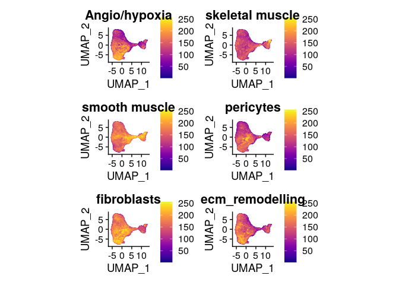

```r
sn_samples_ordered <- c("DollyInjectedCells", "FergieInjectedCells",
                        "AdeleInjectedCells", "CherInjectedCells",
                        "DollyRecellSN", "FergieRecellSN", "AdeleRecellSN",
                        "CherRecellSN")

module_genes <- list("Angio/hypoxia" = c("SEMA3C", "VEGFA", "HIF1A", "P4HA1",
                                         "PLAUR", "PTGS2", "NDRG1", "EGFR",
                                         "POSTN", "VCAN", "LUM"),
                     "skeletal muscle" = c("ACTA1", "MEF2A", "MEF2C"),
                     "smooth muscle" = c("TAGLN", "ACTA2", "CALD1", "CD151",
                                         "KCNMA1", "MYL6", "MYL9", "MYLK",
                                         "DES"),
                     "pericytes" = c("CSPG4", "PDGFRB", "VEGFA", "CCL2",
                                     "COL4A1", "COL4A2", "LOXL2", "OLFML2A"),
                     "fibroblasts" = c("PRRX1", "PRRX2", "ZEB1",
                                       "PCOLCE", "DCN", "LUM", "PDGFRA",
                                       "S100A4"),
                     "ecm_remodelling" = c("MMP1", "MMP16", "ADAM23",
                                           "ADAM10", "ADAM17", "ADAM9",
                                           "ADAMTS6", "ADAMTS10", "ADAMTS17",
                                           "ADAMTS3"))

cells$all_sn <- AddModuleScore(cells$all_sn, features = module_genes)
cluster_col_idxs <- grepl("Cluster", colnames(cells$all_sn@meta.data))
colnames(cells$all_sn@meta.data)[cluster_col_idxs] <- names(module_genes)
p <- FeaturePlot(cells$all_sn, names(module_genes), order = TRUE, cols = viridis::plasma(256)) & coord_equal()
print(p)
```

```r
f_name <- paste0("images/all_sn_module_scores.pdf")
ggsave(plot = p, filename = f_name, height = 20, width = 15)
```

## 2.5 Marker gene expression

Make violin plots of marker genes.

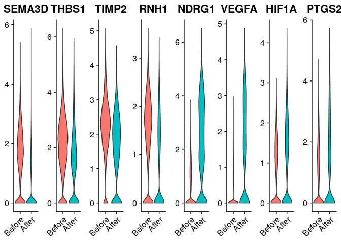

```r
pathway_genes <- c("SEMA3D", "THBS1", "ENSSSCG00000017164", "RNH1", "NDRG1", "VEGFA", "HIF1A", "PTGS2")
cells$all_sn$before_after <- factor(cells$all_sn$before_after,
                                   levels = c("Before", "After"))
p <- lapply(list(pathway_genes),
            function(x) {
                ncol <- length(pathway_genes)
                pl <- VlnPlot(cells$all_sn, group.by = "before_after",
                        features = x,
                        pt.size = 0, combine = FALSE)
                pl <- lapply(pl, function(y) {y + theme(axis.title = element_blank(),
                                                        legend.position = "none")})
                pl <- lapply(pl, function(y) {
                                 if (y$labels$title == "ENSSSCG00000017164") {
                                     y$labels$title <- "TIMP2"
                                 }
                                 return(y)
                        })
                pl <- ggarrange(plotlist = pl, nrow = 1, ncol = ncol)
                return(pl)
            })
p <- ggarrange(plotlist = p, ncol = 1)
f_name <- paste0("images/pathway_marks_vlnplot_all_sn.pdf")
print(p)
```

```r
ggsave(p, height = 4, width = 15, filename = f_name, limitsize = FALSE)
```

## 2.6 Differential abundance analysis

Carry out differential abundance analysis using DA-seq to identify transcriptomic regions with an over- or under-abundance of either pre- or post-bioreactor nuclei.

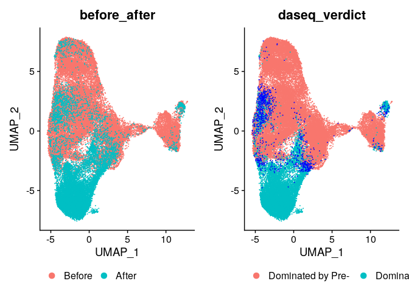

```r
embs <- Embeddings(object = cells$all_sn, reduction = "harmony")
labels <- as.character(cells$all_sn$before_after)
daseq_verdicts <- getDAcells(embs, cell.labels = labels, labels.1 = "Before",
                             labels.2 = "After")

cells$all_sn$daseq_verdict <- "Non-dominated"
cells$all_sn$daseq_verdict[daseq_verdicts$da.up] <- "Dominated by Post-"
cells$all_sn$daseq_verdict[daseq_verdicts$da.down] <- "Dominated by Pre-"
p1 <- DimPlot(cells$all_sn, group.by = "daseq_verdict",
              order = c("Non-dominated", "Dominated by Post-", "Dominated by Pre-"),
              cols = c("#F8766D", "#00BFC4", "blue")) +
        theme(legend.position = "bottom")

DimPlotOrdered <- function(cell_obj, reduction, dims, group.by) {
    group_order <- names(sort(table(cell_obj[[group.by]][, 1])))
    p_ordered <- DimPlot(cell_obj, reduction = reduction, dims = dims,
                         group.by = group.by, order = group_order)

    return(p_ordered)
}

p2 <- DimPlotOrdered(cells$all_sn, reduction = "umap", dims = 1:2,
                     group.by = "before_after") +
        theme(legend.position = "bottom")
p <- ggarrange(p2, p1, nrow = 1)
print(p)
```

```r
ggsave(plot = p, filename = "images/all_sn_before_after_daseq_verdicts_umap.pdf",
       width = 16, height = 8)
```

## 2.7 Clustering analysis

First run clustree to determine the “true” number of clusters, then identify inter-cluster DEGs.

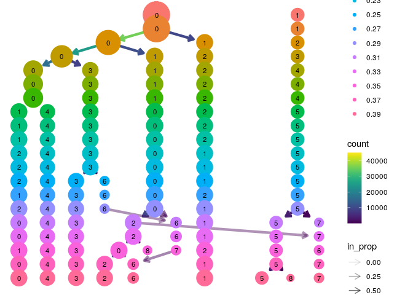

```r
cells$all_sn <- FindNeighbors(cells$all_sn, dims = 1:20, reduction = "harmony")
for (res in seq(0.01, 0.4, 0.02)) {
    message(res)
    cells$all_sn <- FindClusters(cells$all_sn, resolution = res)
}
p <- clustree(cells$all_sn, prefix = "RNA_snn_res.")
print(p)
```

```r
ggsave(plot = p, filename = "images/all_sn_clustree_results.pdf", height = 20)
```

Visualize the five clusters suggested by clustree and look at the expressions of marker genes and the distributions of pre- and post-bioreactor nuclei across them.

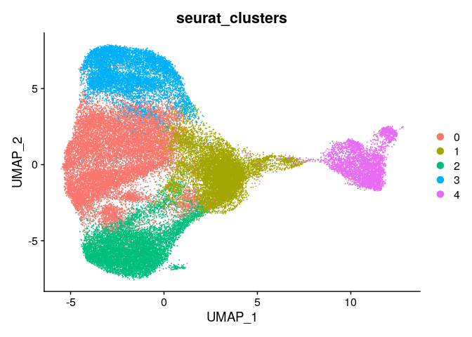

```r
# Res identified by clustree
res <- 0.13
clusts_name <- paste0("RNA_snn_res.", res)
cells$all_sn$seurat_clusters <- cells$all_sn[[clusts_name]]
Idents(cells$all_sn) <- "seurat_clusters"

p <- DimPlot(cells$all_sn, group.by = "seurat_clusters", pt.size = -0.3)
print(p)
```

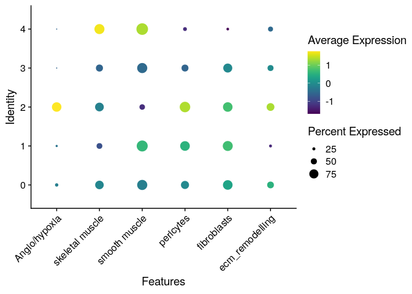

```r
ggsave(paste0("images/DimPlot_all_sn_5_clusts.pdf"), p)


md_mat <- t(as.matrix(cells$all_sn@meta.data[, names(module_genes)]))
md_assay <- CreateAssayObject(data = md_mat, key = "MD_")
cells$all_sn[["MetaData"]] <- md_assay

p <- DotPlot(cells$all_sn, names(module_genes), assay ="MetaData") +
        theme(axis.text.x = element_text(angle = 45, hjust = 1)) +
        scale_color_viridis()
print(p)
```

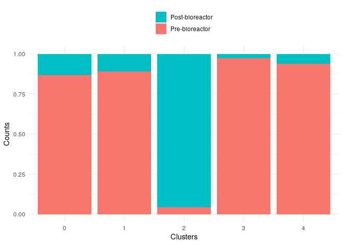

```r
ggsave("images/all_sn_5_clusts_dot_plot_modules.pdf", p, width=7, height=5)

df <- cells$all_sn@meta.data[, c("before_after", "RNA_snn_res.0.13")]
levels(df$before_after) <- c("Pre-bioreactor", "Post-bioreactor")
df$before_after <- factor(df$before_after,
                          levels = c("Post-bioreactor", "Pre-bioreactor"))
p <- ggplot(df, aes(x=RNA_snn_res.0.13, fill=before_after)) +
        geom_bar(position="fill") +
        scale_fill_manual(values = c("Pre-bioreactor"="#F8766D",
                                     "Post-bioreactor"="#00BFC4")) +
        xlab("Clusters") +
        ylab("Counts") +
        theme_minimal() +
        theme(legend.position = "top", legend.title = element_blank(),
              legend.direction = "vertical")
print(p)
```

```r
ggsave("images/pre_post_by_cluster_barplot.pdf", p, height = 4, width = 2.5)
```

Carry out subclustering on each of the five clusters. Again look at the expression of sets of marker genes across each subcluster.

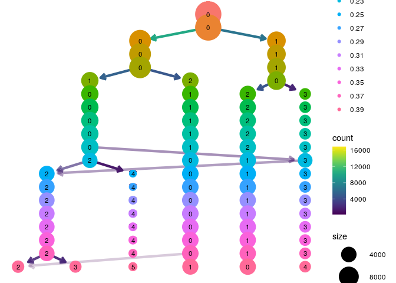

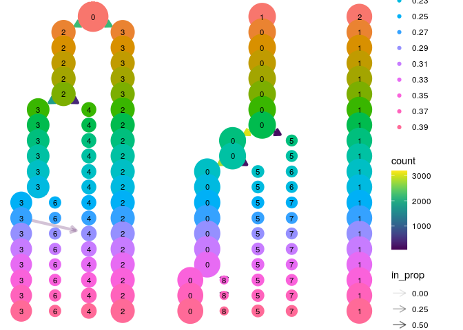

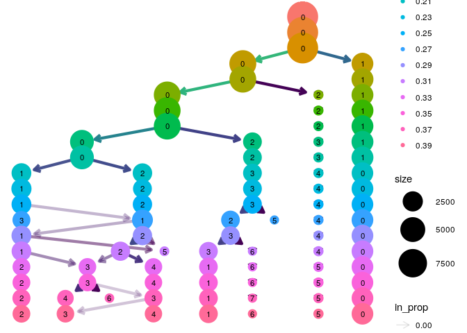

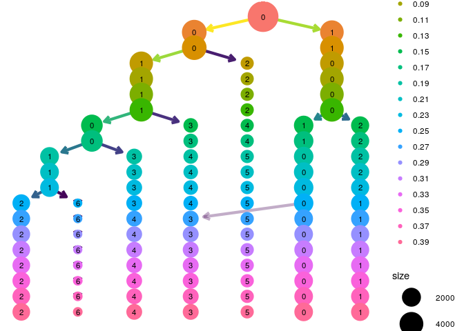

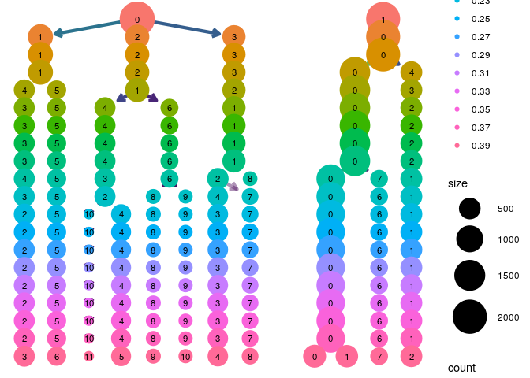

```r
cells$all_sn$before_after <- factor(cells$all_sn$before_after,
                                    levels = c("Before", "After"))

cells_subs <- list()
for (clust in levels(cells$all_sn$seurat_clusters)) {
    message(paste("Sub-clustering cluster", clust))
    cells_sub <- subset(cells$all_sn, seurat_clusters == clust)

    cells_sub <- NormalizeData(cells_sub) %>%
                    FindVariableFeatures() %>%
                    ScaleData() %>%
                    RunPCA() %>%
                    RunHarmony("lane") %>%
                    RunUMAP(dims = 1:20, reduction = "harmony") %>%
                    FindNeighbors(dims = 1:20, reduction = "harmony")

    for (res in seq(0.01, 0.4, 0.02)) {
        message(res)
        cells_sub <- FindClusters(cells_sub, resolution = res)
    }
    cells_subs[[paste0("clust_", clust)]] <- cells_sub
    p <- clustree(cells_sub, prefix = "RNA_snn_res.")
    print(p)
    ggsave(plot = p,
           filename = paste0("images/all_sn_clust", clust, "clustree.pdf"),
           height = 20)
}
```

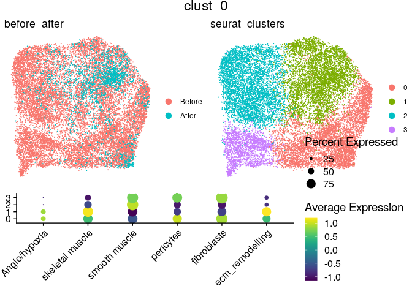

[figure not shown]

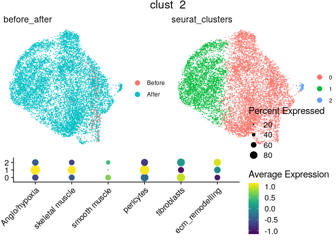

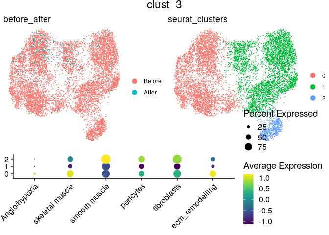

[figure not shown]

```r
clustree_verdicts <- list("clust_0" = 0.13, "clust_1" = 0.03, "clust_2" = 0.11,
                          "clust_3" = 0.07, "clust_4" = 0.03)
for (clust in names(clustree_verdicts)) {
    pt_size <- -0.3
    res_name <- paste0("RNA_snn_res.", clustree_verdicts[[clust]])
    Idents(cells_subs[[clust]]) <- res_name
    cells_subs[[clust]]$seurat_clusters <- Idents(cells_subs[[clust]])

    before_after_dp <- DimPlot(cells_subs[[clust]], group.by = "before_after",
                               pt.size = pt_size,
                               order = c("After", "Before")) +
                        theme_void()
    clusts_dp <- DimPlot(cells_subs[[clust]], group.by = "seurat_clusters", pt.size = pt_size) + theme_void()

    cells_subs[[clust]] <- AddModuleScore(cells_subs[[clust]],
                                          features = module_genes)
    cluster_col_idxs <- grepl("Cluster",
                              colnames(cells_subs[[clust]]@meta.data))
    colnames(cells_subs[[clust]]@meta.data)[cluster_col_idxs] <- names(module_genes)

    top_row <- ggarrange(before_after_dp, clusts_dp)

    dot_plot <- DotPlot(cells_subs[[clust]], features = names(module_genes)) +
                    theme(axis.text.x = element_text(angle = 45, hjust = 1),
                          axis.title = element_blank()) +
                    scale_color_viridis()

    p_title <- ggplot() +
                annotate("text", x = 0, y = 0, size = 6, label = clust) +
                theme_void()
    p <- ggarrange(p_title, top_row, dot_plot, ncol = 1,
                   heights = c(0.03, 0.5, 0.3))

    print(p)
    ggsave(paste0("images/all_sn_clust_", clust, "_all_plots.pdf"), p, height=10, width=10)
}
```

```r
# Clustree also says to use 0.29
clustree_to_use <- "RNA_snn_res.0.29"
Idents(cells$all_sn) <- cells$all_sn[[clustree_to_use]][, 1]
```

Plot heatmaps of DEGs in pre- and post-bioreactor nuclei.

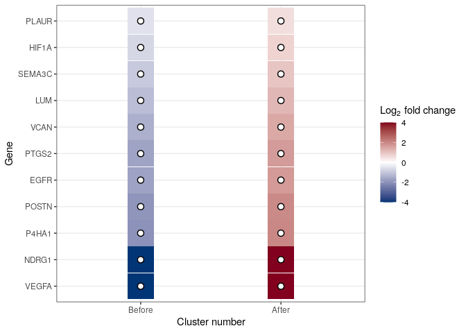

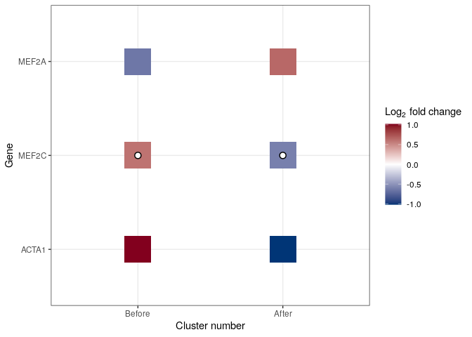

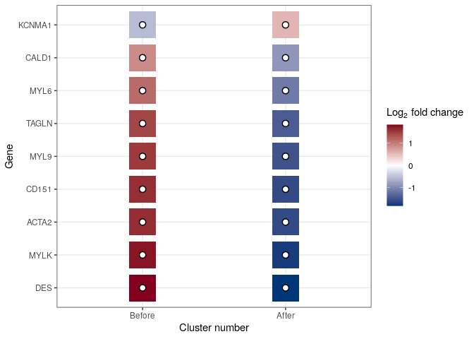

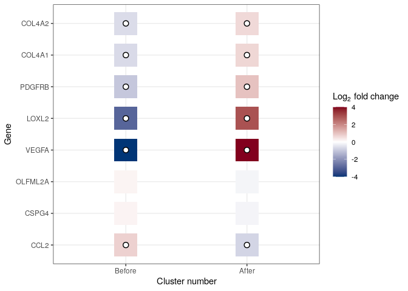

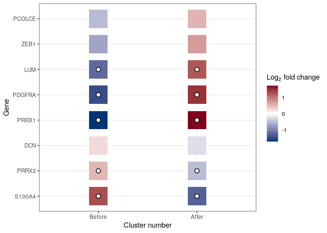

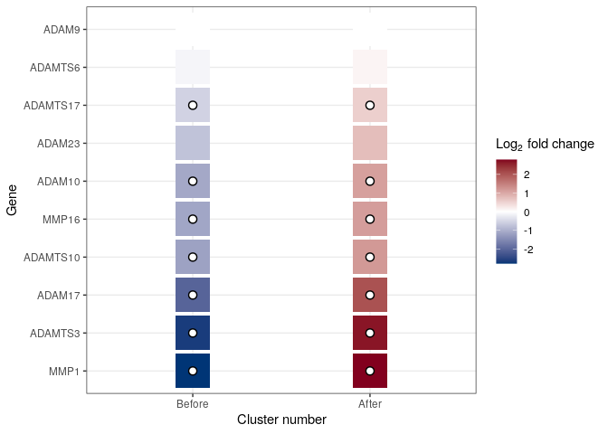

```r
marks_dfs_list <- list("before_after" = list(), clustree_to_use = list())
marks <- custom_FindMarkers(cells$all_sn, grouping_col = "sample",
                            md_colnames = names(module_genes),
                            grep(x = sn_samples_ordered, pattern = "Recell",
                                 value = TRUE),
                            grep(x = sn_samples_ordered, pattern = "Injected",
                                 value = TRUE),
                            latent_vars = c("lane", "technology"))
marks_dfs_list$before_after$marker_sets <- marks

if (compilation_level >= 1) {
    marks_dfs_list$before_after$marker_sets_genes <- marks_after_before
    marks_dfs_list$before_after$marker_genes <- marks_after_before
} else {
    # If DEGs haven't been computed this time, then load them from file
    marks_dfs_list$before_after$marker_sets_genes <- read.csv("out_data/after_before_degs_all_sn_lane_covar_LR_test.csv")
    marks_dfs_list$before_after$marker_genes <- read.csv("out_data/after_before_degs_all_sn_lane_covar_LR_test.csv")
}

de_modules_list <- list()
for (clust in levels(cells$all_sn[[clustree_to_use]][, 1])) {
    message(clust)
    marks <- custom_FindMarkers(cells$all_sn, grouping_col = clustree_to_use,
                                md_colnames = names(module_genes),
                                clust,
                                setdiff(levels(cells$all_sn[[clustree_to_use]][, 1]), clust),
                                latent_vars = c("lane", "technology"))
    marks$cluster <- clust
    de_modules_list[[clust]] <- marks
}
de_modules_list <- do.call(rbind, de_modules_list)

p <- DotPlot(cells$all_sn, features = unique(unlist(c(module_genes))),
             group.by = "before_after", scale = TRUE,
             cols = c("lightgrey", "#FF2600")) +
        theme(axis.text.x = element_text(angle = 45, hjust = 1))

dot_plot_df <- p[[1]]
md <- "marker_sets_genes"
marks_sub_pval <- subset(marks_dfs_list[["before_after"]][[md]], p_val_adj <= 0.05)

# If FindMarkers has been run (instead of FindAllMarkers), add
# placeholder cluster information as a new column in the df (as
# this is assumed to exist by the plotting code)
if (is.null(marks_sub_pval$cluster)) {
    tmp_list <- list()
    for (clust in unique(cells$all_sn[["before_after"]][, 1])) {
        tmp_list[[clust]] <- marks_sub_pval
        tmp_list[[clust]]$cluster <- clust
    }
    marks_sub_pval <- do.call(rbind, tmp_list)
}

sig_degs_df <- data.frame(id = marks_sub_pval$cluster,
                          features.plot = marks_sub_pval$gene)

dot_plot_df$features.plot <- recode(dot_plot_df$features.plot, ENSSSCG00000017164 = "TIMP2")
sig_degs_df$features.plot <- recode(sig_degs_df$features.plot, ENSSSCG00000017164 = "TIMP2")

dot_plot_df$lfc <- NA
for (g in unique(dot_plot_df$features.plot)) {
    df_sub <- subset(dot_plot_df, features.plot == g)
    for (i in unique(df_sub$id)) {
        in_expr <- df_sub[df_sub$id == i, "avg.exp"]
        out_expr <- mean(df_sub[df_sub$id != i, "avg.exp"])
        min_val <- min(in_expr, out_expr)
        if (min_val < 0) {
            # If we have negative "expression" (probably not from
            # genes, but rather from module scores), then shift so
            # that the minimum is 1 to avoid taking logs of
            # negative values
            in_expr <- in_expr - min_val + 1
            out_expr <- out_expr - min_val + 1
        }
        dot_plot_df[(dot_plot_df$id == i) & (dot_plot_df$features.plot == g), "lfc"] <- log2(in_expr / out_expr)
    }
}

for (gene_module in names(module_genes)) {
    genes_to_plot <- module_genes[[gene_module]]
    df_sub <- subset(dot_plot_df, features.plot %in% genes_to_plot)
    p <- DotPlot_square(df_sub, sig_degs_df)
    gene_module_safe <- gsub(x = gene_module,
                             pattern = "[/, ]",
                             replacement = "_")
    file_name <- paste0("images/heatmap_plus_dots_all_sn_before_after_", md, "_module_",
                        gene_module_safe, ".pdf")
    print(p)
    ggsave(plot = p, filename = file_name,
           height = 0.5 + (0.2 * nrow(df_sub)),
           width = 3.8)
}
```

# 3 Spatial transcriptomic data

Load the ST data.

```r
new_st_samples <- c("Cher_Graft_V", "Cher_native_V", "Cher_ReCell_V",
                "Fergie_Graft_V", "PVA", "PVB", "PVC", "PVD")
st_samples_orig_names <- new_st_samples
old_st_samples <- c("Native_1_ST", "Native_2_ST", "Native_3_ST")
st_samples <- c(old_st_samples, new_st_samples)
for (s in st_samples) {
    dir_name <- paste0("data/", s, "/outs")
    cells[[s]] <- Load10X_Spatial(data.dir = dir_name)
    cells[[s]] <- add_visual_reduction(cells[[s]])
    cells[[s]][["x"]] <- Embeddings(cells[[s]], "visual")[, 2]
    cells[[s]][["y"]] <- Embeddings(cells[[s]], "visual")[, 1]
    cells[[s]] <- SCTransform(cells[[s]], assay = "Spatial")
    cells[[s]]$entropy <- apply(GetAssayData(cells[[s]]), 2, entropy.empirical)
}

exclusion_csv_dir <- "data/exclusion_csvs"
for (f_name in dir(exclusion_csv_dir)) {
    s <- strsplit(f_name, "\\.")[[1]][1]
    f_path <- paste0(exclusion_csv_dir, "/", f_name)
    excluded_barcodes <- read.csv(f_path)$Barcode
    cells[[s]] <- cells[[s]][, !colnames(cells[[s]]) %in% excluded_barcodes]
}

new_samples_renames <- list("PVA" = "Adele_Graft_V", "PVB" = "Beyonce_Graft_V",
                            "PVC" = "Dolly_Graft_V", "PVD" = "Ella_Graft_V")
names(cells) <- sapply(names(cells),
                       function(y) {
                           if (y %in% names(new_samples_renames)) {
                               new_samples_renames[[y]]
                           } else {
                               y
                           }})
new_st_samples <- sapply(new_st_samples,
                       function(y) {
                           if (y %in% names(new_samples_renames)) {
                               new_samples_renames[[y]]
                           } else {
                               y
                           }})
st_samples <- c(old_st_samples, new_st_samples)
```

## 3.1 Cell type classification

Merge the ST data, then cluster it to identify cell types.

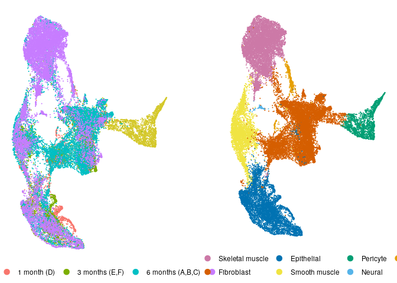

```r
rename_sample_list <- list("Native_1_ST" = "Native DP1",
                           "Native_2_ST" = "Native DP2",
                           "Native_3_ST" = "Native DP3",
                           "Cher_native_V" = "Native (C)",
                           "Fergie_Graft_V" = "3 months (F)",
                           "Cher_Graft_V" = "6 months (C)",
                           "Cher_ReCell_V" = "Pre-implant",
                           "Adele_Graft_V" = "6 months (A)",
                           "Beyonce_Graft_V" = "6 months (B)",
                           "Dolly_Graft_V" = "1 month (D)",
                           "Ella_Graft_V" = "3 months (E)")
# For reverse searching:
rename_sample_list_rev <- setNames(names(rename_sample_list),
                                   rename_sample_list)
for (s in names(rename_sample_list)) {
    cells[[s]][["sample"]] <- rename_sample_list[[s]]
    names(cells[[s]]@images)[1] <- rename_sample_list[[s]]
}

set.seed(123)
cells$merged_all_st <- merge(x = cells[st_samples[1]][[1]],
                             y = cells[st_samples[-1]],
                             add.cell.ids = st_samples)

cells$merged_all_st <- SCTransform(cells$merged_all_st, assay = "Spatial") %>%
                        RunPCA() %>%
                        RunHarmony("sample", assay.use = "SCT") %>%
                        RunUMAP(reduction = "harmony", dims = 1:20)

cells$merged_all_st <- FindNeighbors(cells$merged_all_st,
                                     reduction = "harmony",
                                     dims = 1:20) %>%
                        FindClusters(resolution = 0.08)

cells$merged_all_st$merged_cell_type <- "Unknown"
cells$merged_all_st$merged_cell_type[which(cells$merged_all_st$seurat_clusters == "0")] <- "Fibroblast"
cells$merged_all_st$merged_cell_type[which(cells$merged_all_st$seurat_clusters == "1")] <- "Skeletal muscle"
cells$merged_all_st$merged_cell_type[which(cells$merged_all_st$seurat_clusters == "2")] <- "Epithelial"
cells$merged_all_st$merged_cell_type[which(cells$merged_all_st$seurat_clusters == "3")] <- "Smooth muscle"
cells$merged_all_st$merged_cell_type[which(cells$merged_all_st$seurat_clusters == "4")] <- "Pericyte"
cells$merged_all_st$merged_cell_type[which(cells$merged_all_st$seurat_clusters == "5")] <- "NA"
cells$merged_all_st$merged_cell_type[which(cells$merged_all_st$seurat_clusters == "6")] <- "Neural"

cells$merged_all_st$merged_cell_type <- factor(cells$merged_all_st$merged_cell_type,
                                        levels = c("Skeletal muscle",
                                                   "Fibroblast", "Epithelial",
                                                   "Smooth muscle",
                                                   "Pericyte", "Neural",
                                                   "NA"))
Idents(cells$merged_all_st) <- cells$merged_all_st$merged_cell_type

cells$merged_all_st$sample <- factor(cells$merged_all_st$sample,
                              levels = c("Pre-implant", "1 month (D)",
                                         "3 months (E)", "3 months (F)",
                                         "6 months (A)", "6 months (B)",
                                         "6 months (C)", "Native (C)",
                                         "Native DP1", "Native DP2",
                                         "Native DP3"))

clust_cols <- c("#CC79A7", "#D55E00", "#0072B2", "#F0E442", "#009E73",
                "#56B4E9", "#E69F00", "#000000")

cells$merged_all_st$pooled_sample <- as.character(cells$merged_all_st$sample)
cells$merged_all_st$pooled_sample[grepl(x = cells$merged_all_st$sample, pattern = "3 months")] <- "3 months (E,F)"
cells$merged_all_st$pooled_sample[grepl(x = cells$merged_all_st$sample, pattern = "6 months")] <- "6 months (A,B,C)"
cells$merged_all_st$pooled_sample[grepl(x = cells$merged_all_st$sample, pattern = "Native")] <- "Native"

cells$merged_all_st$pooled_sample <- factor(cells$merged_all_st$pooled_sample, levels = c("Pre-implant", "1 month (D)", "3 months (E,F)", "6 months (A,B,C)", "Native"))

pool_colors <- list("Pre-implant" = "#56B4E9", "1 month (D)" = "#F0E442",
                    "3 months (E,F)" = "#E6AE42",
                    "6 months (A,B,C)" = "#D55E00", "Native" = "#009E73")

umap_theme <- theme_void() + theme(plot.title = element_blank(),
                                   legend.position = "bottom")
umap_by_sample <- DimPlot(cells$merged_all_st, group.by = "sample") + umap_theme

gg_color_hue <- function(n) {
  hues = seq(15, 375, length = n + 1)
  hcl(h = hues, l = 65, c = 100)[1:n]
}

default_colors <- c("#D4C82A", gg_color_hue(4))
names(default_colors) <- levels(cells$merged_all_st$pooled_sample)
umap_by_sample_default_colors <- DimPlot(cells$merged_all_st,
                                         group.by = "pooled_sample",
                                         cols = default_colors,
                                         order = names(pool_colors)) +
                                    umap_theme

umap_by_pool <- DimPlot(cells$merged_all_st, group.by = "pooled_sample",
                        cols = default_colors, order = rev(names(pool_colors))) +
                    umap_theme
umap_by_ct <- DimPlot(cells$merged_all_st, group.by = "merged_cell_type",
                      cols = clust_cols) +
                    umap_theme

p <- ggarrange(umap_by_pool,
               ggplot() + theme_void(),
               umap_by_ct,
               nrow = 1, widths = c(0.45, 0.1, 0.45))
print(p)
```

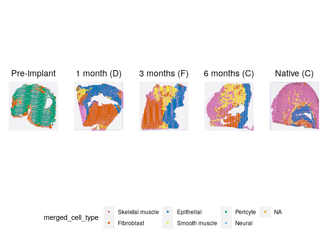

```r
ggsave(p, filename = "images/sample_celltype_umaps.pdf", units = "cm",
       height = 15, width = 30, dpi = 300)

for (s in unique(names(rename_sample_list))) {
    sample_idxs <- which(cells$merged_all_st$sample == rename_sample_list[[s]])
    clusts <- cells$merged_all_st$merged_cell_type[sample_idxs]
    names(clusts) <- NULL
    cells[[s]]$merged_cell_type <- clusts
}

samples_ordered <- rename_sample_list_rev[levels(cells$merged_all_st$sample)]
to_plot <- c("Cher_ReCell_V", "Dolly_Graft_V", "Fergie_Graft_V",
             "Cher_Graft_V", "Cher_native_V")
plot_list <- lapply(samples_ordered[samples_ordered %in% to_plot],
                    function(s) {
                        p <- SpatialDimPlot(cells[[s]],
                                       group.by = "merged_cell_type",
                                       stroke = 0) +
                            scale_fill_manual(values = clust_cols,
                                              drop = FALSE) +
                            ggtitle(rename_sample_list[[s]]) +
                            theme (plot.title = element_text(hjust = 0.5))
                        FixSpatialPlot(p)
                    })

p <- ggarrange(plotlist = plot_list, common.legend = TRUE, legend = "bottom",
               ncol = length(to_plot), nrow = 1)
print(p)
```

```r
ggsave(p, filename="images/merged_st_clustered_cell_types_overlay.pdf",
       units = "cm", width = 30, height = 10, dpi = 300)
```

Plot proportion of cell types in each sample.

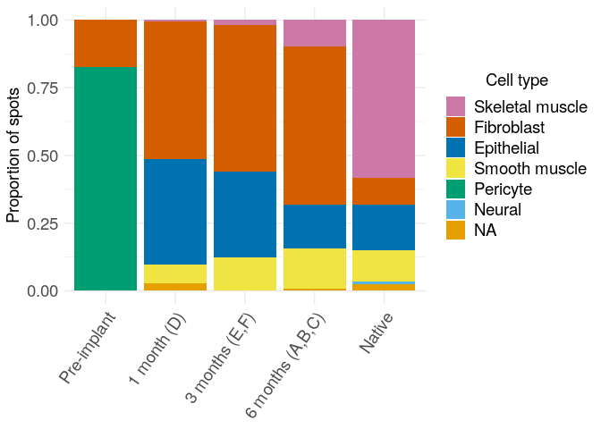

```r
p <- ggplot(cells$merged_all_st@meta.data,
            aes(x = pooled_sample, fill = merged_cell_type)) +
    geom_bar(position = "fill") +
    ylab("Proportion of spots") +
    labs(fill = "Cell type") +
    scale_fill_manual(values = clust_cols) +
    theme_minimal() +
    theme(axis.text.x = element_text(angle = 55, hjust = 1, size = 14),
          axis.text.y = element_text(size = 14),
          axis.title.x = element_blank(),
          axis.title.y = element_text(size = 14),
          legend.text = element_text(size = 14),
          legend.title = element_text(size = 14, hjust = 0.5))
print(p)
```

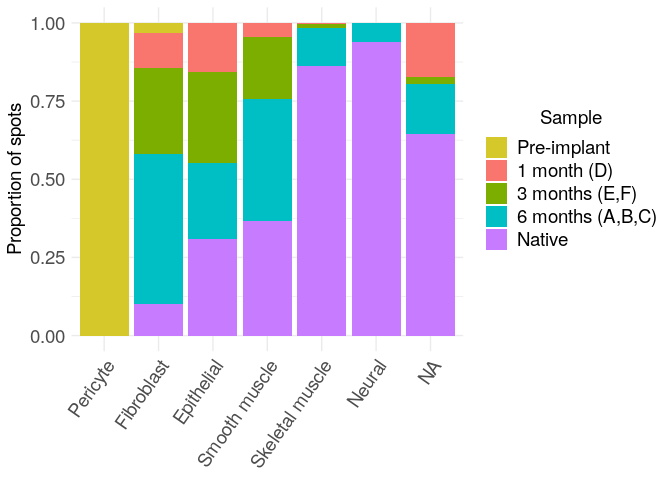

```r
file_name <- paste0("images/merged_st_clustered_cell_types_bar_chart_by_pooled_sample.pdf")
ggsave(p, filename = file_name, units = "cm", width = 15, height = 15,
       dpi = 300)

df_to_plot <- cells$merged_all_st@meta.data
df_to_plot$merged_cell_type <- as.character(df_to_plot$merged_cell_type)
df_to_plot$merged_cell_type <- factor(df_to_plot$merged_cell_type, levels = c("Pericyte", "Fibroblast", "Epithelial", "Smooth muscle", "Skeletal muscle", "Neural", "NA"))
p <- ggplot(df_to_plot,
            aes(fill = pooled_sample, x = merged_cell_type)) +
        scale_fill_manual(values = default_colors) +
        geom_bar(position = "fill") +
        ylab("Proportion of spots") +
        labs(fill = "Sample") +
        theme_minimal() +
        theme(axis.text.x = element_text(angle = 55, hjust = 1, size = 14),
              axis.text.y = element_text(size = 14),
              axis.title.x = element_blank(),
              axis.title.y = element_text(size = 14),
              legend.text = element_text(size = 14),
              legend.title = element_text(size = 14, hjust = 0.5))
print(p)
```

```r
file_name <- paste0("images/merged_st_sample_by_cluster_bar_chart_by_pooled_sample.pdf")
ggsave(p, filename = file_name, units = "cm", width = 15, height = 15,
       dpi = 300)
```